# RPSL - Study 3 - V2

```r
rm(list=ls()) # clear workspace
# load(".RData") # load saved workspace image for this file

# Directories
setwd(dirname(rstudioapi::getSourceEditorContext()$path))
```

# Paths

```r
# Data Path
data_path <- 'C:/Users/Ava/Desktop/Experiments/statistical_learning/1_data/exp_3'
# Code Path
code_path <- 'C:/Users/Ava/Desktop/Experiments/statistical_learning/2_code/exp_3'
# Results Path
res_path <- 'C:/Users/Ava/Desktop/Experiments/statistical_learning/3_results/exp_3'
fig_path <- file.path(res_path,'/figures')
```

Init.

##Load

# — Target Detection Task

# 0 - PREPROCESSING

```r
hist(rt_data$rt)
summary(rt_data$rt)
count(sort(rt_data$rt) < 100)
```

# 1 - PLOTS

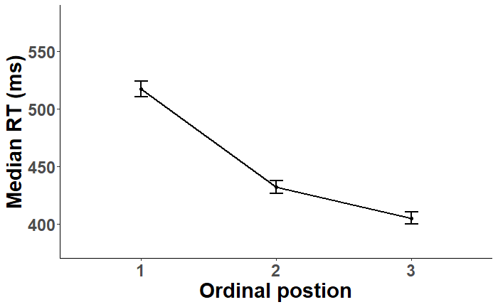

```r
rt_data_sum1 <- rt_data %>% # target position x block
    summarySE(measurevar = "rt", groupvars = c("block","tgt_pos"),na.rm=TRUE)
rt_data_sum2 <- rt_data %>% # target position only
    summarySE(measurevar = "rt", groupvars = c("tgt_pos"),na.rm=TRUE)

ggplot() +
 # geom_point(data = rt_data_sum1, mapping = aes(x=tgt_pos,y=rt_median, colour = factor(block)), size = 2) +
#  geom_line(data = rt_data_sum1, mapping = aes(x = tgt_pos, y = rt_median, group = block, colour = factor(block)),size = .5) +
  geom_point(data = rt_data_sum2, mapping = aes(x = tgt_pos, y = rt_median), colour = "BLACK") +
  geom_errorbar(data = rt_data_sum2, mapping = aes(x = tgt_pos, y = rt_median, ymin = rt_median-ci, ymax = rt_median+ci), colour = "BLACK", width = 0.1, size = 0.8) +
  geom_line(data = rt_data_sum2, mapping = aes(x = tgt_pos, y = rt_median, group = 1), colour = "BLACK", size = .9) +

  scale_colour_brewer(palette = "Paired") +
  scale_y_continuous(limits=c(380,580)) +
  #  annotate("text", x = 3.4, y = 570, label = paste("N =",toString(N))) +
  #labs(colour= "Block") +
  ylab('Median RT (ms)') + xlab('Ordinal postion') +
  theme_classic() +
  theme(text = element_text(family = "LM Roman 10", face="bold",size = 22)) +
#  ggsave(file.path(res_path,'figures','fig1a_rt_pos_block.png'), width = w, height = h)
  ggsave(file.path(fig_path,'fig1a_rt_pos_avg.png'), width = w, height = h)
```

```r
# dev.copy(pdf,file.path(res_path,'figures','fig1artposblock.pdf'), width = 6, height = 4)
# dev.off()
```

## Fig. 1b. Plot RT ~ Pos (Raincloud)

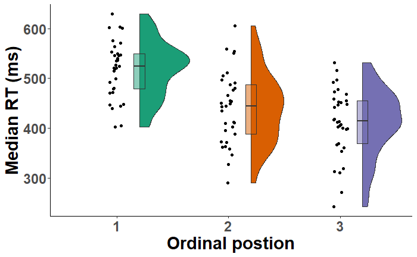

```r
rt_data_sum3 <- rt_data %>% # target position x subject
    summarySE(measurevar = "rt", groupvars = c("tgt_pos","subject"),na.rm=TRUE)

ggplot(rt_data_sum3, aes(x = tgt_pos, y = rt_median, fill = tgt_pos)) +
  geom_point(position = position_jitter(width = .07)) +
  geom_flat_violin(position = position_nudge(x = 0.2, y = 0), adjust = 0.8, trim = TRUE) +
  geom_boxplot(width = 0.1, alpha = 0.5, position = position_nudge(x=0.2,y=0)) +
  #scale_fill_manual(values=wes_palette("Royal2")[c(3,4,5)]) +
  scale_fill_brewer(palette="Dark2") +
#  scale_fill_manual(values = c("#ABABAB", "#757575", "#454545")) +
#  scale_y_continuous(limits=c(380,580)) +
  ylab('Median RT (ms)') + xlab('Ordinal postion') +
  guides(fill = FALSE, color = FALSE) +
  theme_classic() +
  theme(text = element_text(family = "LM Roman 10", face="bold",size=22)) +
  ggsave(file.path(fig_path,'fig1b_rt_pos_grey.png'), width = w, height = h)
```

## Plot RT ~ Pos x Block x Subject

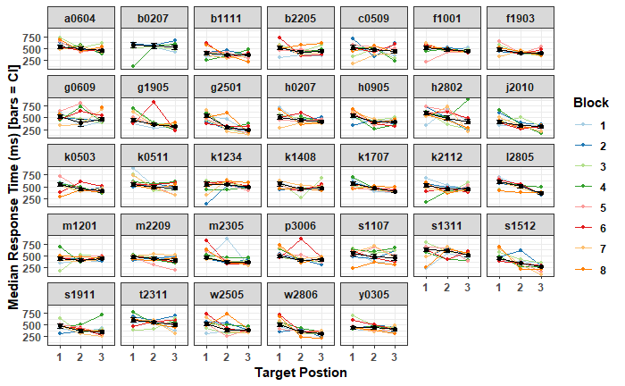

## Plot Blocks as Facets

| tgt_pos | target_num | block | N | moving_mean_mean | moving_mean_median | sd | se | ci |
| --- | --- | --- | --- | --- | --- | --- | --- | --- |
| 1 | 1 | 1 | 15 | 496.6533 | 485.4000 | 142.06390 | 36.68074 | 78.67237 |
| 1 | 1 | 2 | 21 | 473.5762 | 454.2000 | 149.26415 | 32.57211 | 67.94423 |
| 1 | 1 | 3 | 15 | 549.8200 | 507.4000 | 145.09591 | 37.46360 | 80.35144 |
| 1 | 1 | 4 | 16 | 528.8438 | 520.3500 | 121.74070 | 30.43517 | 64.87104 |
| 1 | 1 | 5 | 18 | 508.4778 | 493.0000 | 122.45705 | 28.86340 | 60.89646 |
| 1 | 1 | 6 | 17 | 486.3118 | 490.7000 | 121.10984 | 29.37345 | 62.26893 |
| 1 | 1 | 7 | 15 | 463.7200 | 420.8000 | 152.47614 | 39.36917 | 84.43847 |
| 1 | 1 | 8 | 17 | 485.5412 | 490.5000 | 80.54953 | 19.53613 | 41.41475 |
| 1 | 2 | 1 | 14 | 392.7500 | 429.1500 | 163.87428 | 43.79724 | 94.61819 |
| 1 | 2 | 2 | 20 | 513.2450 | 520.6000 | 154.78799 | 34.61165 | 72.44301 |

[output cut: 422 more lines]

# 2 - MODELS

| subject | block | trial | target_num | target | tgt_word | tgt_pos | detect | rt | rt_secs | rt_sc |
| --- | --- | --- | --- | --- | --- | --- | --- | --- | --- | --- |
| a0604 | 1 | 1 | 1 | be | 4 | 2 | 0 | NA | NA | NA |
| a0604 | 1 | 1 | 2 | be | 4 | 2 | 0 | NA | NA | NA |
| a0604 | 1 | 1 | 3 | be | 4 | 2 | 0 | NA | NA | NA |
| a0604 | 1 | 1 | 4 | be | 4 | 2 | 0 | NA | NA | NA |
| a0604 | 1 | 1 | 5 | be | 4 | 2 | 0 | NA | NA | NA |
| a0604 | 1 | 1 | 6 | be | 4 | 2 | 0 | NA | NA | NA |
| a0604 | 1 | 1 | 7 | be | 4 | 2 | 0 | NA | NA | NA |
| a0604 | 1 | 1 | 8 | be | 4 | 2 | 0 | NA | NA | NA |
| a0604 | 1 | 1 | 9 | be | 4 | 2 | 0 | NA | NA | NA |
| a0604 | 1 | 1 | 10 | be | 4 | 2 | 0 | NA | NA | NA |

[output cut: 990 more lines]

## GLMM: RT ~ Pos x Block

### Fuller

```r
options(contrasts = c("contr.sum"))
```

[output not shown]

### *Lesser

```r
  Anova(rt.mod.less.int,type = 2)
```

```
Analysis of Deviance Table (Type II Wald chisquare tests)

Response: rt_secs
         Chisq Df            Pr(>Chisq)
tgt_pos 523.48  2 < 0.00000000000000022 ***
---
Signif. codes:  0 ‘***’ 0.001 ‘**’ 0.01 ‘*’ 0.05 ‘.’ 0.1 ‘ ’ 1
```

Effect Size

```r
pwr.chisq.test(w =, N = 33, df = 2, sig.level = 0.5, power = )
```

#### Model Evaluation

```r
anova(rt.mod.full.int.fct,rt.mod.less.int)
```

Models with a delta AIC of greater than 10 suggest almost no support for the fuller model. For more info, see here: https://stats.stackexchange.com/questions/232465/how-to-compare-models-on-the-basis-of-aic

### Full, Lesser | Random Slopes

```r
load(file.path(res_path,'models','rt_block_full_slope.Rdata'))
#rt.mod.full.int.slope <- glmer(rt_secs ~ 1 + tgt_pos*block + (tgt_pos | subject), data = rt_data, family = Gamma(link = "log"), control = glmerControl(optimizer="bobyqa", optCtrl=list(maxfun=2e5)))
  summary(rt.mod.full.int.slope)
  plot(residuals(rt.mod.full.int.slope))
  qqnorm(resid(rt.mod.full.int.slope))
 #save(rt.mod.full.int.slope, file = file.path(res_path,'models','rt_block_full_slope.Rdata'))

load(file.path(res_path,'models','rt_block_less_slope.Rdata'))
#rt.mod.less.int.slope <- glmer(rt_secs ~ 1 + tgt_pos + (tgt_pos | subject), data = rt_data, family = Gamma(link = "log"))
  summary(rt.mod.less.int.slope)
  plot(residuals(rt.mod.less.int.slope))
  qqnorm(resid(rt.mod.less.int.slope))
 # save(rt.mod.less.int.slope, file = file.path(res_path,'models','rt_block_less_slope.Rdata'))

# Eval
anova(rt.mod.less.int,rt.mod.full.int.slope,rt.mod.less.int.slope)
```

A final comparison, by testing if allowing random slopes for both position and block per subject is a better reflector than only for target position.

### Lesser | Random Slopes for both Factors

```r
#load(file.path(res_path,'models','rt_block_less_slope2.Rdata'))
rt.mod.less.int.slope2 <- glmer(rt_secs ~ 1 + tgt_pos + (tgt_pos | subject) + (block | subject), data = rt_data, family = Gamma(link = "log"), control = glmerControl(optimizer="bobyqa", optCtrl=list(maxfun=2e5)))
summary(rt.mod.less.int.slope2)
plot(residuals(rt.mod.less.int.slope2))
qqnorm(resid(rt.mod.less.int.slope2))
save(rt.mod.less.int.slope2, file = file.path(res_path,'models','rt_block_less_slope2.Rdata'))

# Model comparison
anova(rt.mod.less.int,rt.mod.less.int.slope,rt.mod.less.int.slope2)
```

Yet again, go for the simplest model.

## Contrasts

```r
emm.pos
```

```
$emmeans
 tgt_pos response     SE  df asymp.LCL asymp.UCL
 1          0.534 0.0150 Inf     0.499     0.570
 2          0.456 0.0127 Inf     0.426     0.486
 3          0.424 0.0117 Inf     0.396     0.452

Confidence level used: 0.95
Conf-level adjustment: sidak method for 3 estimates

$contrasts
 contrast estimate      SE  df z.ratio p.value
 1 - 2      0.0785 0.00570 Inf 13.770  <.0001
 1 - 3      0.1104 0.00582 Inf 18.964  <.0001
 2 - 3      0.0319 0.00438 Inf  7.285  <.0001

P value adjustment: tukey method for comparing a family of 3 estimates
```

```r
# library(broom)
# tidy(rt.mod.less.int,conf.int=TRUE) %>% as_tibble()
# # all fit values
# glance(rt.mod.less.int)
# # plot estimates
# tidy(rt.mod.less.int,conf.int=TRUE) %>% as_tibble() %>%
#   .[c(1:3),] %>%
#   ggplot(aes(term, estimate, ymin=conf.low, ymax=conf.high)) +
#   geom_pointrange() +
#   geom_hline(yintercept = 0)
#
# # augment pulls out the fitted estimate and the residuals for all observations
# augment(rt.mod.less.int) %>%
#    ggplot(aes(x=.fitted, y=.resid)) +
#   geom_point() +
#   geom_smooth()
```

## Plot Contrasts: RT ~ Pos

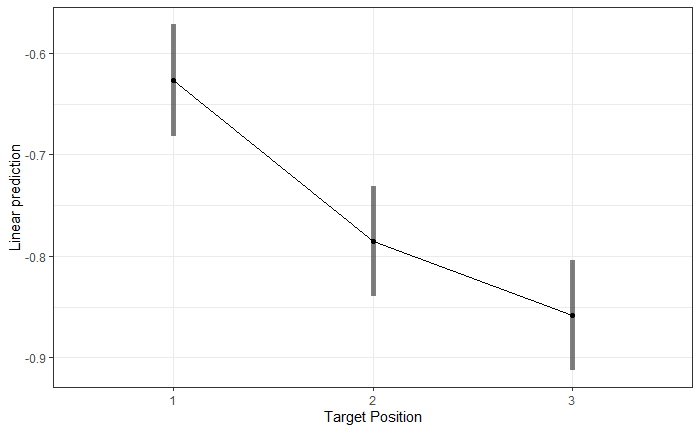

## Block Contrasts

[output not shown]

## Fig. 1c. Contrasts: RT ~ Pos | Block

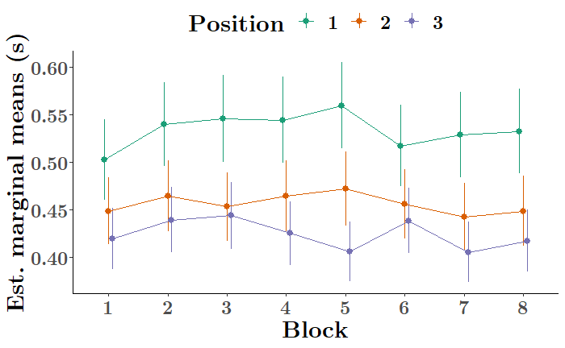

```
NOTE: Results may be misleading due to involvement in interactions
```

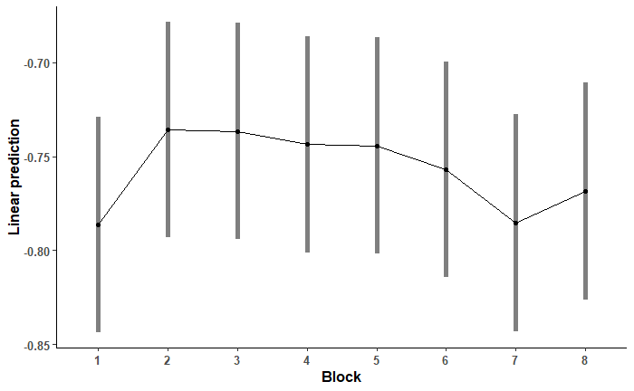

```r
emmip(rt.mod.full.int.fct, ~ block, CIs = TRUE, xlab = "Block") +
 theme_classic() +
  theme(text = element_text(family = "LM Roman 10", face="bold", size = 12))
```

## Contra Honey: Controls

```r
(pairing.emm <- emmeans(pairings.glm, spec = pairwise ~ pairs, adjust = "Tukey", transform = "response"))
```

```
NOTE: Results may be misleading due to involvement in interactions
```

```
$emmeans
 pairs emmean   SE  df lower.CL upper.CL
 c1.2    58.4 10.7 613    32.82     84.1
 c2.3    28.1 10.7 613     2.46     53.8
 c1.3    87.7 10.7 606    62.10    113.3

Results are averaged over the levels of: block
Degrees-of-freedom method: inherited from kenward-roger when re-gridding
Confidence level used: 0.95
Conf-level adjustment: sidak method for 3 estimates

$contrasts
 contrast    estimate   SE  df t.ratio p.value
 c1.2 - c2.3     30.3 11.2 613  2.712  0.0188
 c1.2 - c1.3    -29.3 11.2 606 -2.622  0.0243
 c2.3 - c1.3    -59.6 11.2 606 -5.333  <.0001

Results are averaged over the levels of: block
Degrees-of-freedom method: inherited from kenward-roger when re-gridding
P value adjustment: tukey method for comparing a family of 3 estimates
```

## Fig. S2. RT Delta ~ ., Block

```
NOTE: Results may be misleading due to involvement in interactions
```

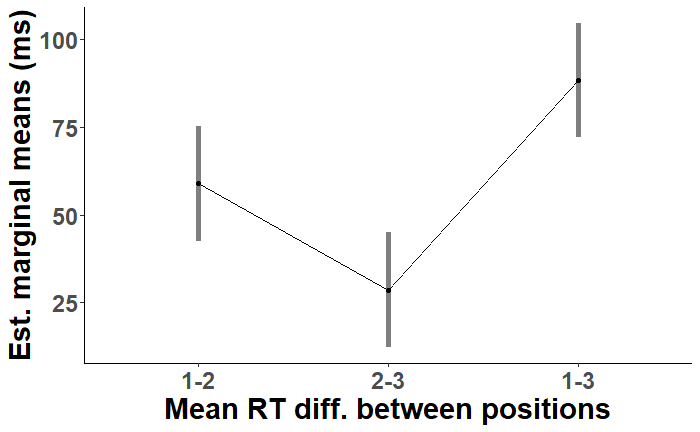

```r
emmip(pairings.aov, ~ pairs, CIs=TRUE, type = "response",size = 10) +
  scale_x_discrete(name = "Mean RT diff. between positions", labels=c("1-2","2-3","1-3")) +
  scale_y_continuous(name="Est. marginal means (ms)") +
  theme_classic() +
  theme(text = element_text(family = "LM Roman 10", face="bold", size = 22))
```

#### Block 1 vs 8

```r
Anova(block.lm)
```

```
Anova Table (Type II tests)

Response: rt_mean
           Sum Sq  Df F value Pr(>F)
block       34143   7  0.8521 0.5452
Residuals 1442520 252
```

## Fig. S2c: RT ~ Target Num

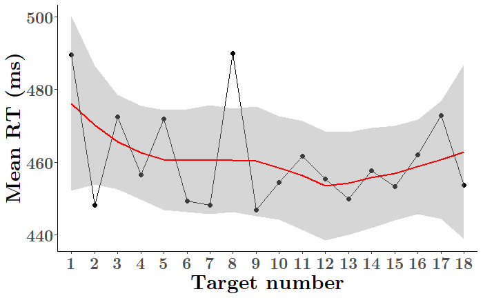

#### Target Num

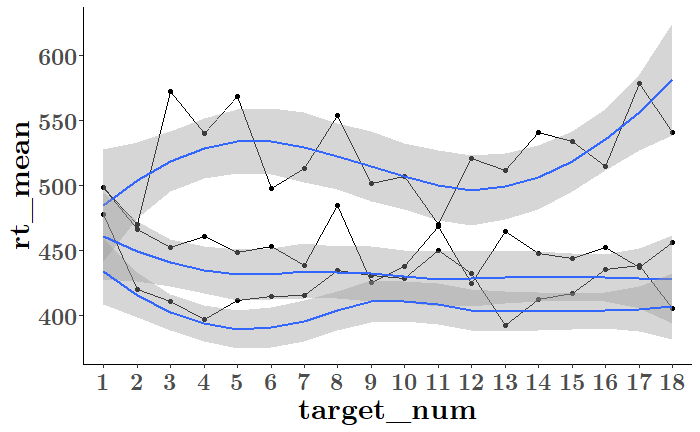

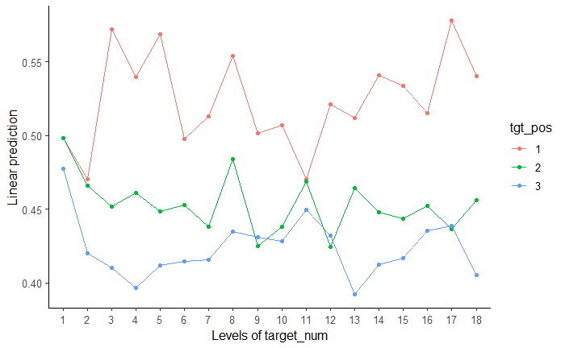

# 3 - ACCURACY STATS

### Stats

| subject | block | trial | target_num | target | tgt_word | tgt_pos | detect | rt | rt_secs | rt_sc |
| --- | --- | --- | --- | --- | --- | --- | --- | --- | --- | --- |
| a0604 | 1 | 1 | 1 | be | 4 | 2 | 0 | NA | NA | NA |
| a0604 | 1 | 1 | 2 | be | 4 | 2 | 0 | NA | NA | NA |
| a0604 | 1 | 1 | 3 | be | 4 | 2 | 0 | NA | NA | NA |
| a0604 | 1 | 1 | 4 | be | 4 | 2 | 0 | NA | NA | NA |
| a0604 | 1 | 1 | 5 | be | 4 | 2 | 0 | NA | NA | NA |
| a0604 | 1 | 1 | 6 | be | 4 | 2 | 0 | NA | NA | NA |
| a0604 | 1 | 1 | 7 | be | 4 | 2 | 0 | NA | NA | NA |
| a0604 | 1 | 1 | 8 | be | 4 | 2 | 0 | NA | NA | NA |
| a0604 | 1 | 1 | 9 | be | 4 | 2 | 0 | NA | NA | NA |
| a0604 | 1 | 1 | 10 | be | 4 | 2 | 0 | NA | NA | NA |

[output cut: 990 more lines]

Now: Accuracy of 0.70 and sd of 0.45. Previously: Average accuracy is 0.73 with an SD of 0.26. Precision (true positives/true + false positives) is at 0.80 with an SD of 0.23.

### a. Accuracy per position

```r
    as.data.frame(emmeans(pos.lm, specs = pairwise ~ tgt_pos)$contrasts)$estimate/sigmaHat(pos.lm)
```

```
[1] -0.8400029 -1.7055452 -0.8655423
```

#### -> Subsample to show robustness

|  | contrast | estimate | SE | df | z.ratio | p.value | d |
| --- | --- | --- | --- | --- | --- | --- | --- |
| 1 | 1 - 2 | 0.07734912 | 0.005884397 | Inf | 13.14478 | 0.000000e+00 | 0.22160903 |
| 2 | 1 - 3 | 0.11166239 | 0.006084779 | Inf | 18.35110 | 0.000000e+00 | 0.31991824 |
| 3 | 2 - 3 | 0.03431327 | 0.004979779 | Inf | 6.89052 | 1.669909e-11 | 0.09830921 |

### a. Accuracy ~ Pos

```r
accuracy_data1 <- rt_data %>% summarySE(measurevar = "detect", groupvars = c("tgt_pos","subject"),na.rm=TRUE)
accuracy_data2 <- rt_data %>% summarySE(measurevar = "detect", groupvars = c("tgt_pos"),na.rm=TRUE)

# Boxplot
# ggplot(accuracy_data2) +
#   geom_col(mapping=aes(tgt_pos, detect_mean, fill= (tgt_pos)),
#            position = position_dodge(0.5), width=0.5) +
#   geom_errorbar(mapping=aes(tgt_pos, y=detect_mean, ymin=detect_mean-se, ymax=detect_mean+se,
#            group=tgt_pos,color=tgt_pos), position=position_dodge(0.5), width = 0.3, size = 1) +
#   scale_y_continuous(limits = c(0,1), name = "mean detection accuracy [bars = SEM]") +
#   scale_x_discrete(name = "Target Position") +
#   scale_color_brewer(palette="Dark2") +
#   scale_fill_brewer(palette="Pastel2") +
#   guides(fill=FALSE, color = FALSE) +
#   theme_minimal() +
#   theme(text = element_text(family = "LM Roman 10", face="bold")) +
#   ggsave(file.path(res_path,'figures','fig4_rt_acc.png'),width=w,height=h)

# Raincloud
ggplot(accuracy_data1, aes(x = tgt_pos, y = detect_mean, fill = tgt_pos)) +
  geom_point(position = position_jitter(width = .07)) +
  geom_flat_violin(position = position_nudge(x = 0.2, y = 0), adjust = 1, trim = FALSE) +
  geom_point(accuracy_data2, mapping = aes(tgt_pos, detect_mean), position = position_nudge(x = 0.2, y = 0)) +
  geom_errorbar(accuracy_data2, mapping=aes(tgt_pos, y=detect_mean, ymin=detect_mean-se,
                                            ymax=detect_mean+se),
                position = position_nudge(x = 0.2, y = 0), width = 0.05, size = 1) +
  #scale_fill_manual(values=wes_palette("Royal2")[c(3,4,5)]) +
  scale_color_brewer(palette="Dark2") +
  scale_fill_brewer(palette="Pastel2") +
  scale_y_continuous(limits = c(0,1), name = "mean detection accuracy [bars = SEM]") +
  scale_x_discrete(name = "Target Position") +
  guides(fill = FALSE, color = FALSE) +
  theme_minimal() +
  theme(text = element_text(family = "LM Roman 10", face="bold")) +
  ggsave(file.path(res_path,'figures','fig4_rt_acc.png'),width=w,height=h)
dev.copy(pdf,file.path(res_path,'figures','exp3fig4acc.pdf'), width = w, height = h)
dev.off()
```

### b. Accuracy ~ word

```r
as.data.frame(em.word$contrasts)$estimate/sigmaHat(word.lm)
```

```
[1]  0.33723174  0.31357461  1.35850034 -0.02365713  1.02126860  1.04492573
```

```r
ggplot(accuracy_data5, aes(x = tgt_word, y = detect_mean, fill = tgt_word)) +
  geom_point(position = position_jitter(width = .07)) +
  geom_flat_violin(position = position_nudge(x = 0.2, y = 0), adjust = 1, trim = FALSE) +
  geom_point(accuracy_data4, mapping = aes(tgt_word, detect_mean), position = position_nudge(x = 0.2, y = 0)) +
  geom_errorbar(accuracy_data4, mapping=aes(tgt_word, y=detect_mean, ymin=detect_mean-se,
                                            ymax=detect_mean+se),
                position = position_nudge(x = 0.2, y = 0), width = 0.05, size = 1) +
  scale_fill_manual(values=wes_palette("Zissou1")[c(1,3,4,5)]) +
  scale_y_continuous(limits = c(0,1), name = "mean detection accuracy [bars = SEM]") +
  scale_x_discrete(name = "Pseudoword", labels = c("nugadi","rokise","mipola","zabetu")) +
  guides(fill = FALSE, color = FALSE) +
  theme_minimal() +
  theme(text = element_text(family = "LM Roman 10", face="bold")) +
  ggsave('fig4b_rt_acc.png',width=w,height=h)
dev.copy(pdf,file.path(res_path,'figures','exp3fig4bacc.pdf'), width = w, height = h)
dev.off()


# ggplot(tgt_acc_word_sum1, mapping=aes(y=accuracy_mean, x=tgt_word)) +
#   geom_point(aes(color=subject)) +
#   geom_boxplot(aes(group=as.factor(tgt_word)), alpha = .3, width = .3) +
#   xlab("Target Word") +
#   ylab("Mean detection accuracy") +
#   theme_minimal() +
#   theme(text = element_text(family = "LM Roman 10", face="bold"), legend.position="none") +
#   ggtitle("B.") +
#   ggsave(file.path(res_path,'/figures/', '/targetdetection_accuracy_word.png'), width = w, height = h)
```

### c Accuracy per Syllable

|  | contrast | estimate | SE | df | t.ratio | p.value |
| --- | --- | --- | --- | --- | --- | --- |
| 3 | nu - ro | 0.2746759 | 0.04483006 | 382 | 6.127048 | 1.462638e-07 |
| 6 | nu - mi | 0.1809059 | 0.04448388 | 382 | 4.066774 | 3.323891e-03 |
| 9 | nu - za | 0.2315487 | 0.04448388 | 382 | 5.205228 | 2.037564e-05 |
| 10 | nu - be | 0.3084303 | 0.04483006 | 382 | 6.879989 | 1.608566e-09 |
| 13 | ga - ro | 0.2330333 | 0.04483006 | 382 | 5.198148 | 2.110726e-05 |
| 19 | ga - za | 0.1899061 | 0.04448388 | 382 | 4.269100 | 1.471230e-03 |
| 20 | ga - be | 0.2667877 | 0.04483006 | 382 | 5.951090 | 3.948823e-07 |
| 22 | di - ro | 0.3338172 | 0.04483006 | 382 | 7.446280 | 3.010125e-11 |
| 25 | di - mi | 0.2400471 | 0.04448388 | 382 | 5.396273 | 7.742056e-06 |
| 28 | di - za | 0.2906900 | 0.04448388 | 382 | 6.534727 | 1.341597e-08 |

[output cut: 21 more lines]

## Fig. S1a. Accuracy - Syllable

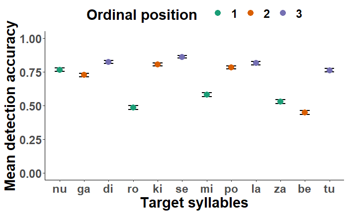

```r
ggplot()+
#  accuracy_data6, aes(x = target, y = detect_mean)) +
  #geom_point(position = position_jitter(width = .07), aes(color = tgt_pos)) +
  #geom_flat_violin(position = position_nudge(x = 0.2, y = 0), adjust = 1, trim = FALSE,fill = "gray") +
  geom_errorbar(accuracy_data7, mapping=aes(target, y=detect_mean, ymin=detect_mean-se,
                ymax=detect_mean+se), position = position_nudge(x = 0, y = 0), width = 0.4, size = 1) +
  geom_point(accuracy_data7, mapping = aes(target, detect_mean, color = tgt_pos), size = 4, position = position_nudge(x = 0, y = 0)) +
  scale_color_brewer(palette="Dark2") +
#  scale_color_manual(values = c("#ABABAB", "#757575", "#454545")) +
  scale_y_continuous(limits = c(0,1), name = "Mean detection accuracy") +
  scale_x_discrete(name = "Target syllables") +
  guides(fill = FALSE) + labs(color = "Ordinal position") +
  theme_classic() +
  theme(text = element_text(family = "LM Roman 10", face="bold",size = 22),
        legend.position = "top")+
  ggsave(file.path(fig_path,'accuracy_syll_greys.png'),width=7,height=6)
```

```r
NA
NA
```

# -> Regress out syllable effect

|  | contrast | estimate | SE | df | z.ratio | p.value |
| --- | --- | --- | --- | --- | --- | --- |
| 1 | 1 - 2 | 78.49998 | 5.632362 | Inf | 13.937311 | 0.000000e+00 |
| 2 | 1 - 3 | 110.37529 | 5.762079 | Inf | 19.155462 | 0.000000e+00 |
| 3 | 2 - 3 | 31.87531 | 4.317759 | Inf | 7.382374 | 4.864997e-13 |

## Prove it didn’t change bc of OR

Check: some accuracy test… -.-

```r
rt_data_cleaned.2 %>%
  summarise(mean = mean(detect),
            sd = sd(detect))

after <- rt_data %>% summarySE(measurevar = "detect", groupvars = c("subject"),na.rm=TRUE)
before <- rt_data_cleaned.2 %>% summarySE(measurevar = "detect", groupvars = c("subject"),na.rm=TRUE)

t.test(after$detect_mean, before$detect_mean, alternative = "two.sided")

rt_data %>% summarySE(measurevar = "detect", groupvars = c("tgt_pos"),na.rm=TRUE)
rt_data_cleaned.2 %>% summarySE(measurevar = "detect", groupvars = c("tgt_pos"),na.rm=TRUE)

rt_data %>% summarySE(measurevar = "detect", groupvars = c("tgt_word"),na.rm=TRUE)
rt_data_cleaned.2 %>% summarySE(measurevar = "detect", groupvars = c("tgt_word"),na.rm=TRUE)

#rt_data %>% summarySE(measurevar = "detect", groupvars = c("target"),na.rm=TRUE)
```

# — Word Recognition

### Summarize Data

```r
# wordrec_data_sum1 <- wordrec_data %>%
#   group_by(subject) %>%
#   summarySE(measurevar = "prop_word_chosen",na.rm=TRUE)

wordrec_data_sum1 <- wordrec_data_orig %>%
  group_by(subject) %>%
  summarySE(measurevar = "prop_word_chosen",na.rm=TRUE)
```

### Fig. 2a. Plot Data

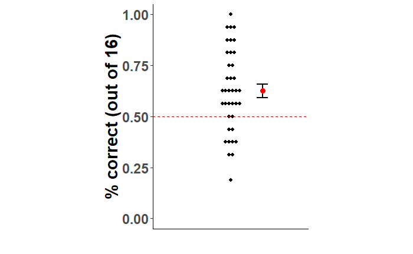

```r
ggplot(wordrec_data_orig, aes(1,prop_word_chosen)) +
  # subjects
  geom_dotplot(binaxis = 'y', stackdir = 'center', dotsize = .5) +
  # mean/se
  geom_errorbar(data = wordrec_data_sum1,
            mapping = aes(x = 1, y = prop_word_chosen_mean, ymin = prop_word_chosen_mean-se,
            ymax = prop_word_chosen_mean+se), position = position_nudge(.2),
            colour = "BLACK", width = 0.07, size = 1) +
  geom_point(data = wordrec_data_sum1,
            mapping = aes(x = 1, y = prop_word_chosen_mean), position = position_nudge(.2),
            colour = "red", size = 3) +
  # baseline
  geom_hline(aes(yintercept = 0.5), colour = "red", linetype = "dashed",show.legend = FALSE) +
  # axes
  scale_x_continuous(name='') + # scale x
  scale_y_continuous(name='% correct (out of 16)',limits=c(0,1)) + # scale y
  coord_fixed(ratio=1.3) +
  # theme
  theme_classic() +
  theme(text = element_text(family = "LM Roman 10", face="bold",size = 22),
        legend.position="none",
        axis.ticks.x = element_blank(),
        axis.text.x = element_blank()) +
  ggsave(file.path(fig_path,'exp3_fig5_wordrec.png'), width = w, height = h)
```

#### T-Tests

```r
# Visualize Data
hist(wordrec_data$prop_word_chosen)
shapiro.test(wordrec_data$prop_word_chosen) # Non-significant difference = normality. Yep, normal.

# ttest
wordrec_ttest <- t.test(wordrec_data_orig$prop_word_chosen, mu = .5,alternative = "greater")
sd(wordrec_data_orig$prop_word_chosen)

# cohen's d - effect size
wr_d <- cohensD(wordrec_data_orig$prop_word_chosen,mu = .5)
```

#### Post-hoc power analysis

```r
# power = 1-beta (type II error -- false reject)
# at p = 0.05
wr_p_05 <- pwr.t.test(d = wr_d, n = length(wordrec_data_orig$subject), sig.level = 0.05, power = NULL,
           alternative = "greater",type = "one.sample")
# at p = .01
wr_p_01 <- pwr.t.test(d = wr_d, n = length(wordrec_data_orig$subject), sig.level = 0.01, power = NULL,
                      alternative = "greater",type = "one.sample")

wr_p_50 <- pwr.t.test(d = wr_d, n = 60, sig.level = 0.05, power = NULL,
           alternative = "greater",type = "one.sample")
wr_p_15 <- pwr.t.test(d = wr_d, n = 15, sig.level = 0.05, power = NULL,
           alternative = "greater",type = "one.sample")
```

### Fig. S3. Wordrec by Word

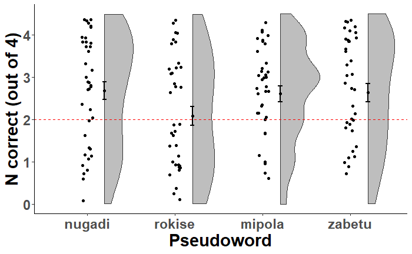

```r
wordrec_data_wrd <- wordrec_data_orig %>%
  gather(key = "word",value = "n_chosen", mipola,nugadi,rokise,zabetu) %>%
  mutate(word = fct_relevel(word,"nugadi","rokise","mipola","zabetu"))


wordrec_data_sum2 <- wordrec_data_wrd %>%
  summarySE(measurevar = "n_chosen", groupvars = "word",na.rm=TRUE) %>%
  mutate(word = fct_relevel(word,"nugadi","rokise","mipola","zabetu"))


ggplot(wordrec_data_wrd, mapping = aes(x=word,y=n_chosen, fill = word)) +
  geom_point(position = position_jitter(width = .07)) +
  geom_flat_violin(position = position_nudge(x = 0.2, y = 0), adjust = 1.2, trim = FALSE, fill = "grey") +
  geom_point(wordrec_data_sum2, mapping = aes(x=word, y=n_chosen_mean),
              position = position_nudge(x = 0.2, y = 0)) +
  geom_errorbar(wordrec_data_sum2, mapping = aes(x=word,y=n_chosen_mean,ymin = n_chosen_mean-se,
                                       ymax = n_chosen_mean+se, group = 1),
                                position = position_nudge(x = 0.2, y = 0), width = 0.05, size = 1) +

  geom_hline(aes(yintercept = 2), colour = "red", linetype = "dashed",show.legend = FALSE) +

  # axes
  scale_x_discrete(name="Pseudoword", labels = ) +
  scale_y_continuous(name="N correct (out of 4)",limits=c(0,4.5)) +
  # theme
 # scale_fill_brewer(palette="Purples") +
 # scale_fill_manual(values=wes_palette("Zissou1")[c(1,3,4,5)]) +
  theme_classic() +
  theme(text = element_text(family = "LM Roman 10", face="bold",size=22),
        legend.position="none") +
  ggsave(file.path(fig_path,'exp3_fig5b_wr_word.png'), width = w, height = h)
```

```r
# dev.copy(pdf,file.path(res_path,'/figures/','exp3fig5b_wr.pdf'), width = w, height = h)
# dev.off()
```

```r
p.s.B
```

```
[1] 0.010126111 0.008436188 1.000000000 0.019886500
```

###### Analysis

```r
wordrec_data_tbl <- data.frame(word=character(),
                 mean = double(),
                 sd = double(),
                 ci_lo = double(),
                 ci_hi = double(),
                 t = double(),
                 df = double(),
                 p_val = double(),
                 stringsAsFactors=FALSE)


## analysis: t-test of each set of responses (to each word) against baseline mean of 2.
word_list <- (unique(wordrec_data_wrd$word))
for (curr_word in word_list) {
  curr_word_data <- wordrec_data_wrd %>%
                    filter(word == curr_word)
  curr_t <- t.test(curr_word_data$n_chosen, mu = 2)
  wordrec_data_tbl[nrow(wordrec_data_tbl)+1,] <- c(curr_word,
                                                   curr_t$estimate,
                                                   sd(curr_word_data$prop_word_chosen),
                                                   curr_t$conf.int[1],
                                                   curr_t$conf.int[2],
                                                   curr_t$statistic,
                                                   curr_t$parameter,
                                                   curr_t$p.value)
  }
wordrec_data_tbl[,2:ncol(wordrec_data_tbl)] <- sapply(wordrec_data_tbl[,2:ncol(wordrec_data_tbl)], as.numeric)
print(wordrec_data_tbl, digits = 2)

wrd.table <- as.data.frame(wordrec_data_tbl)
wrd.table <- wrd.table %>%
  mutate_if(is.numeric, round, digits = 3)
   wrd.table %>%
    kable() %>%
     kable_styling(bootstrap_options = c("striped", "hover")) %>%
     save_kable(file = 'wordrec_individ.png', self_contained = T) #width = w, height = h)
```

On average, participants were able to discriminate 3 out of 4 words from partwords above chance level (2/4).

# —————- Corrlations

## Corr Median Delta with Wordrec

```r
# Generate Deltas for Experiment 3 Data... Delta MEDIANS
rt_data_sum_corr <- rt_data %>%
    group_by(subject) %>%
    mutate(rt_sc.s = scale(rt)) %>% # scale for each subject
    summarySE(measurevar="rt_sc.s", groupvars=c("subject","tgt_pos"), na.rm=TRUE)

options(scipen=999)

exp_3_data_delta <- rt_data_sum_corr %>%
  arrange(subject) %>%
  group_by(subject) %>%
  mutate(delta = rt_sc.s_median - lead(rt_sc.s_median,default=first(rt_sc.s_median))) %>%
  #mutate(delta = rt_median - lead(rt_median,default=first(rt_median))) %>%
  mutate(delta = round(delta,digits=5))

#This works for 1-2 and 2-3, but for 3-1 it pulls the "1" not from the same group, but from the next item in the array.
# Add a column where each rt_median is subtracted by value in n+2, and then shift tha column down so this "1-3" item sits at the tgt_pos 3 row...
exp_3_data_delta <- exp_3_data_delta %>%
    arrange(subject) %>%
    group_by(subject) %>%
    mutate(delta1.3 = rt_sc.s_median - lead(rt_sc.s_median,n=2)) %>%
    mutate(delta1.3 = data.table::shift(delta1.3,n=2))
# take those values in tgt_pos 3 rows...
vals.1.3 <- exp_3_data_delta$delta1.3[which(exp_3_data_delta$tgt_pos==3)]
# add them to the delta col...
exp_3_data_delta$delta[which(exp_3_data_delta$tgt_pos==3)] <- vals.1.3
# and remove the temp col
exp_3_data_delta <- exp_3_data_delta %>% dplyr::select(-delta1.3)

exp_3_data_delta <- exp_3_data_delta %>%
  dplyr::select(subject:N,delta,rt_sc.s_mean:ci) %>%
  #select(subject:N,delta,rt_mean:ci) %>%
  dplyr::rename(., delta_rt = tgt_pos) %>%
  mutate(
    delta_rt = case_when(delta_rt==1 ~ "D1-2",
                         delta_rt==2 ~ "D2-3",
                         delta_rt==3 ~ "D1-3"))
exp_3_data_delta$delta_rt <- factor(exp_3_data_delta$delta_rt, levels = c("D1-2", "D2-3", "D1-3"))
```

Select only word recognition data from participants in the set:

```r
wordrec_data_corr <- wordrec_data_orig[(wordrec_data_orig$subject) %in% unique(exp_3_data_delta$subject),]
exp_3_data_delta <- exp_3_data_delta[(exp_3_data_delta$subject) %in% unique(wordrec_data_corr$subject),]
length(unique(wordrec_data_corr$subject))
```

```
[1] 32
```

Correlate

```r
corr1.2 <- merge(exp_3_data_delta %>% filter(delta_rt == "D1-2") %>%  dplyr::select(delta), wordrec_data_corr %>% dplyr::select(subject, prop_word_chosen))
corr2.3 <- merge(exp_3_data_delta %>% filter(delta_rt == "D2-3") %>%  dplyr::select(delta),wordrec_data_corr %>% dplyr::select(subject, prop_word_chosen))
corr1.3 <- merge(exp_3_data_delta %>% filter(delta_rt == "D1-3") %>%  dplyr::select(delta),wordrec_data_corr %>% dplyr::select(subject, prop_word_chosen))
```

```r
corrtest.1.3
```

```
    Pearson's product-moment correlation

data:  corr1.3$delta and corr1.3$prop_word_chosen
t = 1.2966, df = 30, p-value = 0.1023
alternative hypothesis: true correlation is greater than 0
95 percent confidence interval:
 -0.07075906  1.00000000
sample estimates:
      cor
0.2303548
```

### Fig. S4b. Delta Medians-Offline

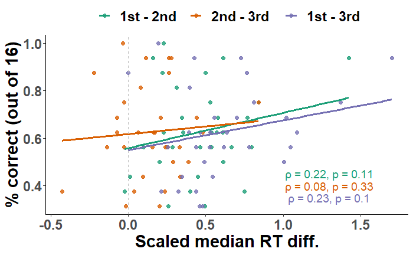

```r
plot.corr <- data.frame(subject = corr1.2$subject,
                        delta1.2 = corr1.2$delta,
                        delta2.3 = corr2.3$delta,
                        delta1.3 = corr1.3$delta,
                        prop.word = corr1.2$prop_word_chosen) %>%
            gather(key = "d.pos", value = "d.med", delta1.2, delta2.3, delta1.3) %>%
            mutate(d.pos = factor(d.pos, levels = c("delta1.2", "delta2.3","delta1.3")))


ggplot(data = plot.corr, aes(d.med, prop.word, color = d.pos)) +
  geom_point(size = 2, alpha = 0.8) +
  geom_smooth(method = lm, se = FALSE, size = 1.1) +
  scale_color_manual(values = RColorBrewer::brewer.pal(3,"Dark2"),
                          #values = c("#7A7F3D", # midway 1-2
  #                               "#A7685B", # mitdway 2-3
  #                               "#488795"), # midway 1-3
                   # values = c("#D44739", "#FAC869", "#3C5E4D"),
                     name = NULL, labels = c("1st - 2nd", "2nd - 3rd", "1st - 3rd")) +
  xlab("Scaled median RT diff.") +
  ylab("% correct (out of 16)") +
annotate(geom = "text", x = 1.3, y = 0.45, label = paste0("\u03C1 = ",round(corrtest.1.2$estimate, digits = 2),", p = ",round(corrtest.1.2$p.value, digits = 2)),
         size = 5, color = RColorBrewer::brewer.pal(3,"Dark2")[1]) + #"#D44739") +
annotate(geom = "text", x = 1.3, y = 0.4, label = paste0("\u03C1 = ",round(corrtest.2.3$estimate, digits = 2),", p = ",round(corrtest.2.3$p.value, digits = 2)),
         size = 5, color = RColorBrewer::brewer.pal(3,"Dark2")[2]) + #"#FAC869") +
annotate(geom = "text", x = 1.3, y = 0.35, label = paste0("\u03C1 = ",round(corrtest.1.3$estimate, digits = 2),", p = ",round(corrtest.1.3$p.value, digits = 2)),
         size = 5, color = RColorBrewer::brewer.pal(3,"Dark2")[3]) + #"#3C5E4D") +
  geom_vline(xintercept = 0, color = "gray", linetype="dashed") +
  theme_classic() +
  theme(text = element_text(family = "LM Roman 10", face="bold",size=22),
        legend.title = element_text(""),  legend.position = "top") +
  ggsave(file.path(fig_path,'fig6_corr_sc_col.png'), width = w, height = h)
```

Corr Mean Delta with Wordrec

```r
# Generate Deltas for Experiment 3 Data... Delta MEDIANS
rt_data_sum_corr <- rt_data %>%
    group_by(subject) %>%
    mutate(rt_sc.s = scale(rt)) %>% # scale for each subject
    summarySE(measurevar="rt_sc.s", groupvars=c("subject","tgt_pos"), na.rm=TRUE)

options(scipen=999)

exp_3_data_delta.mu <- rt_data_sum_corr %>%
  arrange(subject) %>%
  group_by(subject) %>%
  mutate(delta = rt_sc.s_mean - lead(rt_sc.s_mean,default=first(rt_sc.s_mean))) %>%
  mutate(delta = round(delta,digits=5))

#This works for 1-2 and 2-3, but for 3-1 it pulls the "1" not from the same group, but from the next item in the array.
# Add a column where each rt_median is subtracted by value in n+2, and then shift tha column down so this "1-3" item sits at the tgt_pos 3 row...
exp_3_data_delta.mu <- exp_3_data_delta.mu %>%
    arrange(subject) %>%
    group_by(subject) %>%
    mutate(delta1.3 = rt_sc.s_mean - lead(rt_sc.s_mean,n=2)) %>%
    mutate(delta1.3 = data.table::shift(delta1.3,n=2))
# take those values in tgt_pos 3 rows...
vals.1.3 <- exp_3_data_delta.mu$delta1.3[which(exp_3_data_delta.mu$tgt_pos==3)]
# add them to the delta col...
exp_3_data_delta.mu$delta[which(exp_3_data_delta.mu$tgt_pos==3)] <- vals.1.3
# and remove the temp col
exp_3_data_delta.mu <- exp_3_data_delta.mu %>% dplyr::select(-delta1.3)

exp_3_data_delta.mu <- exp_3_data_delta.mu %>%
  dplyr::select(subject:N,delta,rt_sc.s_mean:ci) %>%
  #select(subject:N,delta,rt_mean:ci) %>%
  dplyr::rename(., delta_rt = tgt_pos) %>%
  mutate(
    delta_rt = case_when(delta_rt==1 ~ "D1-2",
                         delta_rt==2 ~ "D2-3",
                         delta_rt==3 ~ "D1-3"))
exp_3_data_delta.mu$delta_rt <- factor(exp_3_data_delta.mu$delta_rt, levels = c("D1-2", "D2-3", "D1-3"))
```

Select only word recognition data from participants in the set:

```r
wordrec_data_corr <- wordrec_data_orig[(wordrec_data_orig$subject) %in% unique(exp_3_data_delta.mu$subject),]
exp_3_data_delta.mu <- exp_3_data_delta.mu[(exp_3_data_delta.mu$subject) %in% unique(wordrec_data_corr$subject),]
```

Correlate

```r
corr1.2.mu <- merge(exp_3_data_delta.mu %>% filter(delta_rt == "D1-2") %>%  dplyr::select(delta), wordrec_data_corr %>% dplyr::select(subject, prop_word_chosen))

corr2.3.mu <- merge(exp_3_data_delta.mu %>% filter(delta_rt == "D2-3") %>%  dplyr::select(delta),wordrec_data_corr %>% dplyr::select(subject, prop_word_chosen))

corr1.3.mu <- merge(exp_3_data_delta.mu %>% filter(delta_rt == "D1-3") %>%  dplyr::select(delta),wordrec_data_corr %>% dplyr::select(subject, prop_word_chosen))
```

```r
corrtest.1.2.mu <- cor.test(corr1.2.mu$delta,corr1.2.mu$prop_word_chosen, method = "pearson")
corrtest.2.3.mu <- cor.test(corr2.3.mu$delta,corr2.3.mu$prop_word_chosen, method = "pearson")
corrtest.1.3.mu <- cor.test(corr1.3.mu$delta,corr1.3.mu$prop_word_chosen, method = "pearson")
```

Fig. 6. Delta Means v. Wordrec

```r
plot.corr.mu <- data.frame(subject = corr1.2.mu$subject,
                        delta1.2 = corr1.2.mu$delta,
                        delta2.3 = corr2.3.mu$delta,
                        delta1.3 = corr1.3.mu$delta,
                        prop.word = corr1.2.mu$prop_word_chosen) %>%
            gather(key = "d.pos", value = "d.mu", delta1.2, delta2.3, delta1.3) %>%
            mutate(d.pos = factor(d.pos, levels = c("delta1.2", "delta2.3","delta1.3")))


ggplot(data = plot.corr.mu, aes(d.mu, prop.word, color = d.pos)) +
  geom_point(size = 2, alpha = 0.8) +
  geom_smooth(method = lm, se = FALSE, size = 1.1) +
  scale_color_manual(values = c("#D44739", "#FAC869", "#3C5E4D"),
                     name = NULL, labels = c("1st - 2nd", "2nd - 3rd", "1st - 3rd")) +
  xlab("proportional change in mean RT") + ylab("P(word chosen over partword)") +
annotate(geom = "text", x = 1.25, y = 0.5, label = paste0("\u03C1 = ",round(corrtest.1.2.mu$estimate, digits = 2),", p = ",round(corrtest.1.2.mu$p.value, digits = 2)), color = "#D44739") +
annotate(geom = "text", x = 1.25, y = 0.45, label = paste0("\u03C1 = ",round(corrtest.2.3.mu$estimate, digits = 2),", p = ",round(corrtest.2.3.mu$p.value, digits = 2)), color = "#FAC869") +
annotate(geom = "text", x = 1.25, y = 0.4, label = paste0("\u03C1 = ",round(corrtest.1.3.mu$estimate, digits = 2),", p = ",round(corrtest.1.3.mu$p.value, digits = 2)), color = "#3C5E4D") +
  geom_vline(xintercept = 0, color = "gray", linetype="dashed") +
  theme_classic() +
  theme(text = element_text(family = "LM Roman 10", face="bold"),
        legend.title = element_text(""),  legend.position = "top") +
  ggsave('fig6_corr_sc_mu.png', width = w, height = h)
```

## Batterink 2017

From Batterink & Paller 2017: “Finally, an “RT score” was computed for each individual participant by subtracting the corrected median RT to third syllable targets from the corrected median RT to first syllable targets, with larger values indicating greater facilitation."

“Mean RT score across participant (computed as the RT difference between first syllable targets and third syllable targets) was 79.1 msec (SD = 59.7), significantly above chance [t(23) ¼ 6.49, p < .001].”

“Performance on the rating task and target detection task significantly correlated across participants (rating score: r = .51, p = .010; rating accuracy: r = .42, p = .044), indicating that learners who performed better on the rating task also showed larger facilitation effects on the target detection task. Given that the rating task provides a measure of explicit memory, this correlation suggests that the target detection task is at least somewhat sensitive to explicit memory as well. Nonetheless, a subgroup of participants (n = 7) who did not achieve above 50% accuracy on the rating task (mean = 45%, SD = 4.4%) still showed a significant RT effect [Corrected RTs: Syllable Position effect: F(2,12) = 6.11, p = .030; linear effect of Syllable Position: F(1,6) = 28.7, p = .002].”

From Batterink et al. 2015: Exp 1: “Correlations were calculated between each participant’s recognition score and their RT priming effect, computed as the RT difference between initial position and final position syllables (RT1–RT3). As shown in Fig. 1B, there was no significant correlation between these two measures (r = .07, p = .75, 95% CI for r = -.34 to .46).”

Exp 2: “As in Experiment 1, the across-subject correlation between recognition scores and the magnitude of the RT priming effect (RT1–RT3) on the target detection task was nonsignif- icant (r = .26, p = .20, 95% CI for r = -.15 to .60). However, this correlation may have been artificially inflated by three participants who showed no behavioral evidence of learning as assessed by either the recognition or the RT measure [criteria: <50% accuracy in recognition task, <10 ms effect (RT1–RT3) in target detection task]. When these three par- ticipants were excluded from the sample, there was still no trend for a correlation between recognition and RT (r=.17, p = .45, 95% CI for r = -.27 to .55).”

Even including “all participants from both experiments, with the exception of the 3 nonlearners identified in Experiment 2 (n = 46). No significant correlation was found between recognition and RT priming (r = .11, p = .47, 95% CI for r = -.19 to .39).”

```r
corrtest.batterink2017
```

```
    Pearson's product-moment correlation

data:  corr.batterink2017$delta and corr.batterink2017$prop_word_chosen
t = 1.2966, df = 30, p-value = 0.1023
alternative hypothesis: true correlation is greater than 0
95 percent confidence interval:
 -0.07075906  1.00000000
sample estimates:
      cor
0.2303548
```

### Fig. S4a. Batterink Online-Offline

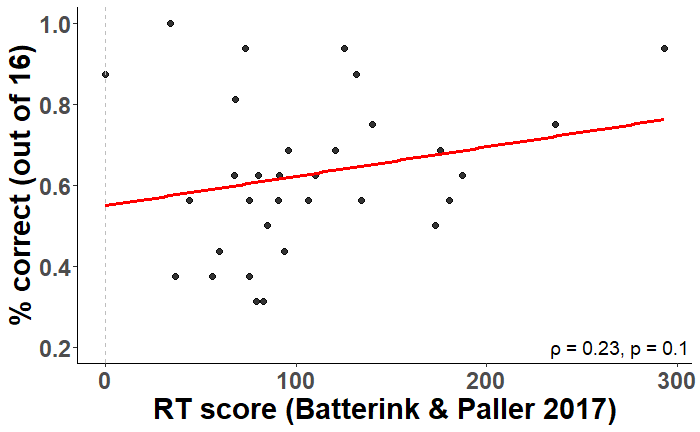

```r
ggplot(data = corr.batterink2017, aes(delta, prop_word_chosen)) +
  geom_point(size = 2, alpha = 0.8) +
  geom_smooth(method = lm, se = FALSE, size = 1.1, color = "red") +
 # scale_color_manual(values = c("#D44739", "#FAC869", "#3C5E4D"),
#                     name = NULL, labels = c("1st - 2nd", "2nd - 3rd", "1st - 3rd")) +
  xlab("RT score (Batterink & Paller 2017)") +
  ylab("% correct (out of 16)") +
annotate(geom = "text", x = 270, y = 0.2,
         label = paste0("\u03C1 = ", round(corrtest.batterink2017$estimate, digits = 2),", p = ",round(corrtest.batterink2017$p.value, digits = 2)),
         size = 5, color = "black") +
  geom_vline(xintercept = 0, color = "gray", linetype="dashed") +
  theme_classic() +
  theme(text = element_text(family = "LM Roman 10", face="bold", size = 22),
        legend.title = element_text(""),  legend.position = "top") +
   ggsave(file.path(fig_path,'batterink_corr.png'), width = w, height = h)
```

```r
NA
```

## Siegelman et al. 2018

Online Measure of SL = log.RT() 1st position) - mean.log.RT(2nd & 3rd position)

```r
# calculate
rt_data_sum_corr.3a <- rt_data %>%
    mutate(rt_log = log(rt)) %>%
    summarySE(measurevar="rt_log", groupvars=c("subject","tgt_pos"), na.rm=TRUE) %>%
    filter(tgt_pos == 1)


rt_data_sum_corr.3b <- rt_data %>%
    mutate(rt_log = log(rt)) %>%
    group_by(subject) %>%
    filter(tgt_pos == 2 || 3) %>%
    summarySE(measurevar="rt_log", groupvars=c("subject"), na.rm=TRUE) %>%
    add_column(tgt_pos = as.factor("2-3"), .after = "subject")

rt_data_sum.corr.3 <- rbind(rt_data_sum_corr.3a,rt_data_sum_corr.3b) %>%
  arrange(subject)


exp_3_data_delta.siegelman2018 <- rt_data_sum.corr.3 %>%
  group_by(subject) %>%
  mutate(delta = rt_log_mean - lead(rt_log_mean)) %>%
  mutate(delta = round(delta,digits=5)) %>%
  dplyr::select(subject:rt_log_median,delta,sd:ci) %>%
  filter(tgt_pos == 1)

# summary
mean(exp_3_data_delta.siegelman2018$delta)
```

```
[1] 0.1149864
```

```r
sd(exp_3_data_delta.siegelman2018$delta)
```

```
[1] 0.1224061
```

```r
# subset
wordrec_data_corr <- wordrec_data_orig[(wordrec_data_orig$subject) %in% unique(exp_3_data_delta.batterink2017$subject),]
exp_3_data_delta.siegelman2018 <- exp_3_data_delta.siegelman2018[(exp_3_data_delta.siegelman2018$subject) %in% unique(wordrec_data_corr$subject),]

# merge
corr.siegelman2018 <- merge(exp_3_data_delta.siegelman2018,
                      wordrec_data_corr %>% dplyr::select(subject, prop_word_chosen))
# correlate
corrtest.siegelman2018 <- cor.test(corr.siegelman2018$delta,
                                   corr.siegelman2018$prop_word_chosen,
                                   method = "pearson",
                                   alternative = "greater"
                                  )
```

## S2b. Siegelman Online-Offline

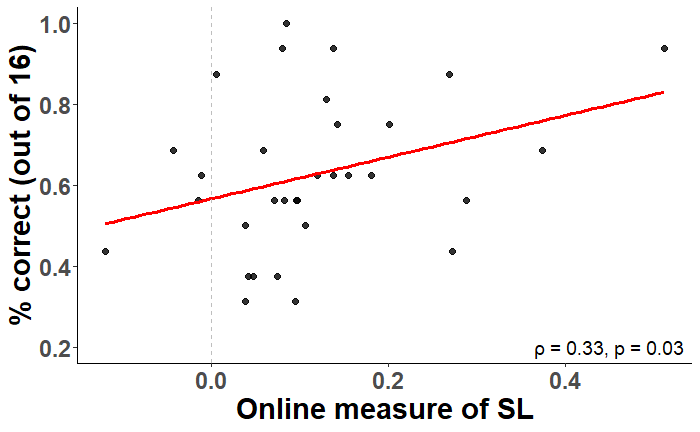

```r
ggplot(data = corr.siegelman2018, aes(delta, prop_word_chosen)) +
  geom_point(size = 2, alpha = 0.8) +
  geom_smooth(method = lm, se = FALSE, size = 1.1, color = "red") +
  scale_color_manual(values = c("#D44739", "#FAC869", "#3C5E4D"),
                     name = NULL, labels = c("1st - 2nd", "2nd - 3rd", "1st - 3rd")) +
  xlab("Online measure of SL") + ylab("% correct (out of 16)") +
annotate(geom = "text", x = 0.45, y = 0.2,
         label = paste0("\u03C1 = ", round(corrtest.siegelman2018$estimate, digits = 2),", p = ",round(corrtest.siegelman2018$p.value, digits = 2)),
         size = 5, color = "black") +
  geom_vline(xintercept = 0, color = "gray", linetype="dashed") +
  theme_classic() +
  theme(text = element_text(family = "LM Roman 10", face="bold",size = 22),
        legend.title = element_text(""),  legend.position = "top") +
  ggsave(file.path(fig_path,'siegelman_corr.png'), width = w, height = h)
```

#—————————- ## Siegelman Analyses

```r
rt_data <- rt_data %>% mutate(rt_log = log(rt))

rt_data_log_sum <- rt_data %>%
  summarySE(measurevar="rt_log", groupvars=c("tgt_pos","block"), na.rm=TRUE)

# ggplot(data = rt_data_log_sum, aes(x = block, y = rt_log_mean, group = tgt_pos, color = tgt_pos)) +
#   geom_point(size = 2, alpha = 0.8) +
#   geom_line(size = 1.5, alpha = 0.5) +
#   geom_smooth(method = "glm", formula = y~x,
#               method.args = list(family = gaussian(link = 'log')),
#               se = TRUE, size = 1, alpha = 0.2) +
#   scale_color_manual(values = c("#D44739", "#FAC869", "#3C5E4D"),
#                      name = NULL, labels = c("1st", "2nd", "3rd")) +
#   xlab("Block") + ylab("Mean log(RT)") +
#   theme_classic() +
#   theme(text = element_text(family = "LM Roman 10", face="bold"),
#         legend.title = element_text("Position"),  legend.position = "right") +
#   ggsave(file.path(res_path,'figures','logRT_block.png'), width = w, height = h)
# dev.copy(pdf,file.path(res_path,'figures','fig1artposblock.pdf'), width = 6, height = 4)
# dev.off()

exp_3_log_traj <- rbind(rt_data_log_sum %>% filter(tgt_pos == 1),
    rt_data %>%
    filter(tgt_pos == 2 || 3) %>%
    summarySE(measurevar="rt_log", groupvars=c("block"), na.rm=TRUE) %>%
    add_column(tgt_pos = as.factor("2-3"), .before = "block"))

exp_3_log_traj.siegelman2018 <- exp_3_log_traj %>%
  arrange(block) %>%
  mutate(delta = rt_log_mean - lead(rt_log_mean)) %>%
  mutate(delta = round(delta,digits=5)) %>%
  dplyr::select(tgt_pos:rt_log_median,delta,sd:ci) %>%
  filter(tgt_pos == 1)
```

## Fig. 1d: Online measure of SL

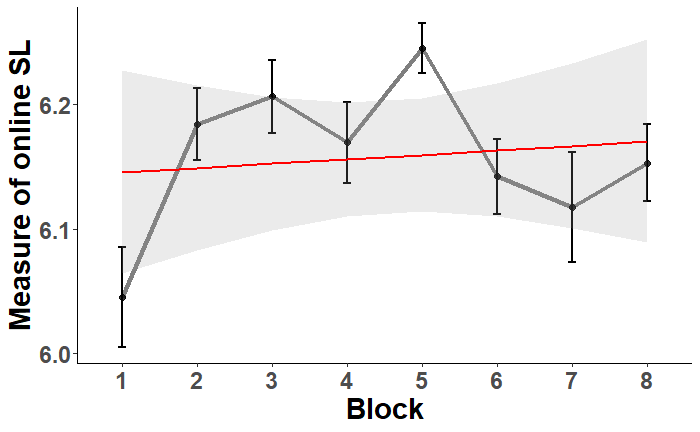

```r
ggplot(data = exp_3_log_traj.siegelman2018, aes(x = block, y = rt_log_mean, group = 1)) +
  geom_point(size = 2, alpha = 0.8) +
  geom_line(size = 1.5, alpha = 0.5) +
  geom_errorbar(mapping = aes(ymin = rt_log_mean-se, ymax = rt_log_mean+se), colour = "BLACK", width = 0.1, size = 0.8) +
  geom_smooth(method = "glm", formula = y~x,
              method.args = list(family = gaussian(link = 'log')),
              se = TRUE, size = 1, alpha = 0.2, color = "red") +
  xlab("Block") +
  ylab("Measure of online SL") +
  #ylab(expression(logRT[1]~-~mu(logRT[2]+logRT[3]))) +
  theme_classic() +
  theme(text = element_text(family = "LM Roman 10", face="bold",size = 22),
        legend.title = element_text("Position"),  legend.position = "right") +
  ggsave(file.path(fig_path,'logRT_block_traj.png'), width = w, height = h)
```

```r
NA
NA
```

```r
exp_3_log_traj_ind <- rbind(rt_data %>%
  summarySE(measurevar="rt_log", groupvars=c("subject","tgt_pos","block"), na.rm=TRUE) %>%
  filter(tgt_pos == 1),
 rt_data %>%
    filter(tgt_pos == 2 || 3) %>%
    summarySE(measurevar="rt_log", groupvars=c("subject","block"), na.rm=TRUE) %>%
    add_column(tgt_pos = as.factor("2-3"), .before = "block")) %>%
  arrange(block,subject)

exp_3_log_traj_ind.siegelman2018 <- exp_3_log_traj_ind %>%
  mutate(delta = rt_log_mean - lead(rt_log_mean)) %>%
  mutate(delta = round(delta,digits=5)) %>%
  dplyr::select(subject:rt_log_median,delta,sd:ci) %>%
  filter(tgt_pos == 1)

library(pbkrtest)
library(emmeans)
emm_options(lmer.df = "satterth")

traj.mod1 <- lmer(delta ~ 1 + block + (1|subject), data = exp_3_log_traj_ind.siegelman2018)
#, family = gaussian(link="log"))

summary(traj.mod1)
Anova(traj.mod1)
emmeans(traj.mod1, specs = pairwise ~ block, adjust = "Tukey",  transform = "response")

# http://www.alexanderdemos.org/ANOVA6.html

# cont <- emmeans(traj.mod1, ~ block) #we already created this
# pairs(cont, adjust='tukey')

descdist(exp_3_log_traj_ind.siegelman2018$rt_log_mean[!is.na(exp_3_log_traj_ind.siegelman2018$rt_log_mean)])
gofstat(fitdist(exp_3_log_traj_ind.siegelman2018$rt_log_mean[!is.na(exp_3_log_traj_ind.siegelman2018$rt_log_mean)],"lnorm"))
denscomp(fitdist(exp_3_log_traj_ind.siegelman2018$rt_log_mean[!is.na(exp_3_log_traj_ind.siegelman2018$rt_log_mean)],"lnorm"))
```

So, nothing new is gained in the above analysis. Using logRT, we find again that there’s no effect of block on reaction times, again likely because the learning is happening in the first few presentations in each block.

#—————————- Corr. Delta / Wordrec per Word

```r
# wrangle
rt_data_sum_corr2 <- rt_data %>% # subject x position x word
  summarySE(measurevar = "rt", groupvars = c("subjID","subject","tgt_pos","tgt_word"),na.rm=TRUE)

rt_data_sum_corr3 <- rt_data %>%
  summarySE(measurevar = "rt", groupvars = c("subjID","subject","tgt_pos","tgt_word","block"),na.rm = TRUE)

# calculate delta_means for each participant:
    # mean_pos3-mean_pos1 / mean_pos1
  delta_means2 <-  data.frame(subj_id=character(),
                            subject=numeric(),
                            word=numeric(),
                            delta_mean=numeric(),
                             stringsAsFactors=FALSE)

    for (subj in unique(rt_data_sum_corr2$subjID)) {
      subj_subset <- rt_data_sum_corr2[which(rt_data_sum_corr2$subjID == subj),]
      for (wrd in unique(subj_subset$tgt_word)) {
        subj_subsubset <- subj_subset %>% filter(tgt_word == wrd)

        subj_delta <- (subj_subsubset$rt_mean[3]-subj_subsubset$rt_mean[1])/subj_subsubset$rt_mean[1]

        delta_means2[nrow(delta_means2) + 1,] = list(subj, subj_subset$subject[1], wrd, subj_delta)
      }
    }

# subject h0207 had no hits on 1st pos. tgts for word 2. try with NA and with 0.
  # -- no outstanding notes for this subject, likely just missed it = "ro"

  # subject b0207 missing data for 1st pos. tgts for word 2.
                        # and for 2nd pos. tgts for word 3. this should be NA.
  # -- this is the subj for whom we lost 1/2 the data set.
delta_means2$delta_mean[is.nan(delta_means2$delta_mean)] <- 0

# ensure same subjects
wordrec_data_corr2 <- wordrec_data[wordrec_data$subj_id %in% unique(rt_data_sum_corr2$subjID),] # correct!

# word 1 = nugadi
# word 2 = rokise
# word 3 = mipola
# word 4 = zabetu

wordrec_byword <- wordrec_data_corr2 %>%
  dplyr::select(subject, subj_id, nugadi, rokise, mipola, zabetu)
wordrec_byword[,3:6]<- wordrec_byword[,3:6]/4
wordrec_byword <- gather(wordrec_byword,key = tgt_word, value = prop_word_chosen, nugadi, rokise, mipola, zabetu)


wordrec_byword$tgt_word[wordrec_byword$tgt_word=="nugadi"] <- 1
  wordrec_byword$tgt_word[wordrec_byword$tgt_word=="rokise"] <- 2
    wordrec_byword$tgt_word[wordrec_byword$tgt_word=="mipola"] <- 3
      wordrec_byword$tgt_word[wordrec_byword$tgt_word=="zabetu"] <- 4

wordrec_byword <- wordrec_byword[order(wordrec_byword$tgt_word),]
wordrec_byword <- wordrec_byword[order(wordrec_byword$subject),]
delta_means2 <- delta_means2[order(delta_means2$word),]
delta_means2 <- delta_means2[order(delta_means2$subject),]


# correlate
corr_mat2 <- cbind(delta_means2,wordrec_byword)
colnames(corr_mat2) <- c("subj_id", "subject", "word", "delta_mean", "subject2", "subj_id2", "tgt_word", "prop_word_chosen")
corr_mat2 <- corr_mat2 %>%
  dplyr::select(subj_id,tgt_word,delta_mean,prop_word_chosen)

corr_mat2 <- corr_mat2 %>%
  mutate(tgt_word = as.factor(tgt_word),
         subj_id = as.factor(subj_id))

SL_cortest2 <- cor.test(corr_mat2$delta_mean,corr_mat2$prop_word_chosen, method = "pearson")

# paired samples
SL_d2 <- cohensD(x = corr_mat2$delta_mean, y = corr_mat2$prop_word_chosen, method = "paired")
```

Fig. A. Plot

```r
# Plot
ggscatter(corr_mat2, x = "delta_mean", y = "prop_word_chosen",
          add = "reg.line", conf.int = TRUE,
          cor.coef = TRUE, cor.method = "pearson",
          xlab = "% change RT (3rd Pos vs. 1st Pos)", ylab = "Prop. correct word recognition") +
  theme_minimal() +
  theme(text = element_text(family = "LM Roman 10", face="bold")) +
  ggtitle('') +
  ggsave(file.path(res_path,'/figures/','/SL_corr-individ.png'), width = w, height = h)
```

Fig. B. Grouped across performance levels

```r
ggplot() +
  geom_point(corr_mat2, mapping = aes(x = prop_word_chosen, y = delta_mean, color = tgt_word),
             size = 1.5) +
  geom_boxplot(corr_mat2, mapping = aes(x = prop_word_chosen, y = delta_mean, group = prop_word_chosen), alpha=0.4, width = .08) +
  scale_x_discrete(name="Prop. words correct (out of 4)",
                    limits=c(0,.25,.5,.75,1)) +
  scale_y_continuous(name="% change RT (3rd Pos vs. 1st Pos)") +
  scale_color_manual(values = word_pal, labels = c("nugadi","rokise","mipola","zabetu")) +
  labs(color="Target Word") +
  theme_minimal() +
  theme(text = element_text(family = "LM Roman 10", face="bold")) +
  ggtitle('') +
  ggsave(file.path(res_path,'/figures/','/corr_sl_individ.png'), width = w, height = h)
```

Fig. C. Plot Individual delta means/word corrects

```r
plot_corr <- corr_mat2 # %>%
            # filter(tgt_word==1)

word_names <- c(`1` = "nugadi",
                `2` = "rokise",
                `3` = "mipola",
                `4` = "zabetu")

w = 10
h = 7
ggplot(plot_corr,aes(x=prop_word_chosen,y=delta_mean,color=tgt_word)) +
  geom_jitter(size=2,width=.01) +
  geom_smooth(method=loess,se=FALSE,fullrange=TRUE) +
  scale_x_discrete(name="Prop. words correct (out of 4)",
                    limits=c(0,.25,.5,.75,1)) +
  scale_y_continuous(name="% change RT (3rd Pos vs. 1st Pos)") +
  facet_grid(.~ tgt_word, labeller = as_labeller(word_names)) +
  scale_color_manual(values = word_pal, guide = FALSE) +
  theme_minimal() +
  theme(text = element_text(family = "LM Roman 10", face="bold")) +
  ggtitle('') +
  ggsave(file.path(res_path,'/figures/','/corr_sl_by_word.png'), width = w, height = h)
```

GLM

```r
# factorize?
corr_mat2 <- corr_mat2 %>%
  mutate(prop_word_chosen_fct = as.factor(prop_word_chosen))

shapiro.test(corr_mat2$delta_mean)
# delta means formally dist.
# logistic regression: categorical variable y =

model.1 <- glmer(prop_word_chosen ~ - 1 + delta_mean + (1 | subj_id) , data = corr_mat2, family = binomial)
summary(model.1)

model.2 <- glmer(prop_word_chosen_fct ~ - 1 + delta_mean*tgt_word + (1 | subj_id) , data = corr_mat2, family = binomial)
summary(model.2)

anova(model.1, model.2) # --> wow, model 2!

allEffects(model.2)
plot(allEffects(model.2))

# model.1 <- glmer(delta_mean ~ - 1 + prop_word_chosen + (1 | subj_id) , data = corr_mat2, family = gaussian)
# summary(model.1)
#
# model.2 <- glmer(delta_mean ~ - 1 + prop_word_chosen*tgt_word + (1 | subj_id) , data = corr_mat2, family = gaussian)
# summary(model.2)
#
# anova(model.1, model.2)

em_sl_corr <- emmeans(model.2, ~ tgt_word | delta_mean)

pairs(em_sl_corr, simple = "each")

slcorr_mc <- contrast((em_sl_corr), interaction = "pairwise")
slcorr_mc_regrid <- contrast(regrid(em_sl_corr), interaction = "pairwise")

# save to kabel
 slcorr.table <- data.frame(Estimate = coef(summary(slcorr_mc)),
                             "Std Error" = summary(slcorr_mc)$test$sigma,
                             "t value" = summary(slcorr_mc)$test$tstat,
                             P = summary(slcorr_mc)$test$pvalues)

  #row.names(tgt.table) <- c("Tgt_Pos1","Tgt_Pos2","Tgt_Pos3")
  #tgt.table$P<- c("<.001","<.001","<.001")
  tgt.table %>%
    kable() %>%
     kable_styling(bootstrap_options = c("striped", "hover")) %>%
     save_kable(file = 'sl_corr_contrasts.png', self_contained = T) #width = w, height = h)
```

TD Accuracy vs. Wordrec

```r
wrd_perf_df <- as.data.frame(wordrec_byword$prop_word_chosen)
acc_word_corr <- cbind(tgt_acc_word_sum1,wrd_perf_df)
names(acc_word_corr)[9] <- "prop_word_chosen"

ggscatter(acc_word_corr, x = "prop_word_chosen", y = "accuracy_mean",
          add = "reg.line", conf.int = TRUE,
          cor.coef = TRUE, cor.method = "pearson",
          xlab = "Prop. words correct", ylab = "Mean Detection Performance") +
  theme_minimal() +
  theme(text = element_text(family = "LM Roman 10", face="bold")) +
  ggsave(file.path(res_path,'/figures/','/tgtdetectaccuracy_prop_word.png'), width = w, height = h)
```

Filter Best-Learned Words

```r
# # word 1 = nugadi
# # word 2 = rokise
# # word 3 = mipola
# # word 4 = zabetu
#
# wordrec_data_learning <- wordrec_data[,c(2,6:9)]
# wordrec_data_learning[wordrec_data_learning<3] <- NA
# wordrec_data_learned <- cbind.data.frame(wordrec_data$subject, wordrec_data_learning)
#   colnames(wordrec_data_learned)[1] <- "subject"
#   wordrec_data_learned <- wordrec_data_learned %>%
#     group_by(subject) %>%
#     dplyr::summarise(n_learned = sum(!is.na(c(mipola,nugadi,rokise,zabetu))),
#                      # calulate proportion correct based only on the ones they learned
#                      prop_learned = sum(mipola,nugadi,rokise,zabetu,na.rm = TRUE)/(n_learned*4))
#   wordrec_data_learned <- cbind.data.frame(wordrec_data_learned[1],wordrec_data_learning,wordrec_data_learned[,2:3])
#
# row_count = 1
# for (subj in wordrec_data_learned$subj_id) {
#   which_learned <- vector()
#   temp <- wordrec_data_learned %>%
#     filter(subj_id == subj)
#     if (!is.na(temp$mipola)) {
#       which_learned <- cbind(which_learned,3)
#     }
#     if (!is.na(temp$nugadi)) {
#       which_learned <- cbind(which_learned,1)
#     }
#     if (!is.na(temp$rokise)) {
#       which_learned <- cbind(which_learned,2)
#     }
#     if (!is.na(temp$zabetu)) {
#       which_learned <- cbind(which_learned,4) }
#   temp$learned <- list(as.list(which_learned))
#
#   if (row_count == 1) {
#     wordrec_data_learnt <- temp
#   } else {
#     wordrec_data_learnt <- rbind(wordrec_data_learnt,temp)
#   }
#   row_count = row_count + 1
# }
# # wordrec_data_learned <- wordrec_data %>%
# #   filter_at(vars(mipola,nugadi,rokise,zabetu), any_vars(. > 2))
# #
# # # number of participants that learned at least one word above chance
# # N_learned_words <- length(unique(wordrec_data_learned$subject))
```

```r
# # For each subject, filter out their data based on the list of numbers in the $learned column,
# # Remove subjects who have NULL in that column
# subjects_none_learned <- wordrec_data_learnt$subj_id[which(wordrec_data_learnt$n_learned==0)]
# # all the others
# wordrec_data_learnt2 <- wordrec_data_learnt[which(wordrec_data_learnt$n_learned>0),]
#
#   # how to check to see if an empty list is empty...
#   # length(unlist(wordrec_data_learnt$learned[19])) # because in a df, an empty list still gives a length of 1, but if you unlist the data, it will give a length of 0
#
# # filter rt_data based on participants who had at least 1 word above chance
# rt_data_learned <- rt_data
# for (subj in subjects_none_learned) {
#   rt_data_learned <- rt_data_learned[!(rt_data_learned$subjID==subj),] }
#
# # filter the rest based on the words they learned
# row_count = 1
# for (subj in unique(rt_data_learned$subjID)) {
#   # find the words that this participant got right
#   words_to_keep <- wordrec_data_learnt2 %>%
#     filter(subj_id == subj)
#   words_to_keep <- unlist(words_to_keep$learned)
#   # filter the rt_data by that word
#   temp <- rt_data_learned %>%
#     filter(subjID == subj) %>%
#     filter(tgt_word %in% words_to_keep)
#   # build new
#   if (row_count == 1) {
#     rt_data_learnt <- temp
#   } else {
#     rt_data_learnt <- rbind(rt_data_learnt,temp)
#   }
#   row_count = row_count + 1
# }
```

Corr Learned Words Delta Means

```r
# rt_data_learnt
# wordrec_data_learnt2
#
# # wrangle -- need to reduce RTs down to means for each position
# rt_data_learnt_sum_corr <- rt_data_learnt %>% # subject x position
#   summarySE(measurevar = "rt", groupvars = c("subjID","subject","tgt_pos"),na.rm=TRUE)
#
# # calculate delta_means for each participant:
#     # mean_pos3-mean_pos1 / mean_pos1
#   delta_means_learnt <-  data.frame(subj_id=character(), subject=numeric(), delta_mean=numeric(),
#                            stringsAsFactors=FALSE)
#   for (subj in unique(rt_data_learnt_sum_corr$subjID)) {
#     subj_subset <- rt_data_learnt_sum_corr[which(rt_data_learnt_sum_corr$subjID == subj),]
#     subj_delta <- (subj_subset$rt_mean[3]-subj_subset$rt_mean[1])/subj_subset$rt_mean[1]
#     delta_means_learnt[nrow(delta_means_learnt) + 1,] = list(subj, subj_subset$subject[1], subj_delta)
#   }
#
# # ensure same subjects
# wordrec_data_learnt2_corr <- wordrec_data_learnt2[wordrec_data_learnt2$subj_id %in% unique(rt_data_learnt_sum_corr$subjID),] # correct!
#
# # correlate
# corr_mat_learnt <- cbind(delta_means_learnt, wordrec_data_learnt2_corr$prop_learned)
# colnames(corr_mat_learnt) <- c("subj_id", "subject",  "delta_mean", "prop_learned")
#
# SL_cortest_learnt <- cor.test(corr_mat_learnt$delta_mean,
#                                corr_mat_learnt$prop_learned, method = "pearson")
#
# # paired samples
# SL_d_learnt <- cohensD(x = corr_mat_learnt$delta_mean,
#                         y = corr_mat_learnt$prop_learned, method = "paired")
#
# # Plot
# ggscatter(corr_mat_learnt, x = "delta_mean", y = "prop_learned",
#           add = "reg.line", conf.int = TRUE,
#           cor.coef = TRUE, cor.method = "pearson",
#           xlab = "% change RT (3rd Pos vs. 1st Pos)", ylab = "Prop. correct word recognition") +
#   #annotate("text", x = 0.29, y = 0.63, label = paste("N =",toString(N))) +
#   ggtitle('Online & Offline SL Performance for words learned (3 or 4 / 4)') +
#   ggsave(file.path(res_path,'/figures/','/SL_corr_learnedbest.png'), width = w, height = h)
#
# # Analyze
# fit <- lm(prop_learned ~ delta_mean, data = corr_mat_learnt)
#   summary(fit)
#   plot(fit)
```